# Problem Set 06

Lauren Sullivan, BIO_SC 8002_01

Due Mar 25, 2022

## Urbanization and spiders

### Background

We will be examining data from: Dahirel et al. 2019. Urbanization-driven changes in web building and body size in an orb web spider. Journal of Animal Ecology. 88:79-91. Here are links to the [paper](https://besjournals.onlinelibrary.wiley.com/doi/epdf/10.1111/1365-2656.12909) and [data](https://datadryad.org/stash/dataset/doi:10.5061/dryad.j886dg0).

*Note: I would encourage you to check out the format with which they provided their data and code. These authors did a particularly good job as they provided data, code and metadata (this is not as common as I’d like - now that I’m scrounging Dryad for datasets for our class.) These authors store their data in a way that I encourage, which is multiple files for different types of data that can be joined through tidying data before analysis. So this is a great example! I also fully realize you could look at their code and use it to inform your homework answers, but I encourage you to challenge yourself and try it without looking at the code and instead working in your groups. I won’t be asking you for the exact same analyses they do in their paper, so try to answer the homework questions without looking, and then check out their code later (it’s beatifully commented).*

In this paper, the authors examine orb weaver spiders (check them out [here](https://en.wikipedia.org/wiki/Araneus_diadematus)) and how their body size and web building changes with urbanization. Orb weaver spiders are particularly interesting because their behavior can be understood by measuring their web’s characteristics. For example, when spiders experience low prey capture, they will increase the capture area of their web to make sure they catch something. Alternatively, they will build smaller webs with finer structure to maximize prey retention when prey density is high. So tracking web size and construction can allow for an understanding of the resource availability a spider is facing. We will be using their data to practice mixed effects models that follow both normal and non-normal distributions.

### Setup

```r
###############
#
# 06 PROBLEM SET
#
# DUE:        March 25, 2022
#
# CREATED BY: Lauren Sullivan
# FILES:      "population_densities.csv"
#             "urbanization.csv"
#             "spiders.csv"
#
###############


########### setup
rm(list=ls())


library(tidyverse)
library(lme4)  #mixed effects models
library(lmerTest)  #pvalues for lme4
library(MuMIn)  #variance components
library(bbmle)  #for AICtab()
library(car)  #for Anova()
library(emmeans) #for contrasts
library(multcomp) #for contrasts


########### data
popden <- read_csv("../data/population_densities.csv")
urbanization <- read_csv("../data/urbanization.csv")
spiders <- read_csv("../data/spiders.csv")

## you can find the metadata for these files in the associated "READ_ME" files on Canvas
```

**Q1** Look at the three datasets the authors used and how they are organized. Using the metadata, please describe what each dataset is telling you, and how they are organized. Why is it helpful to have the data organized in this way, as three separate files? What do you like about the presentation of their work? What would you change?

```r
# "population_densities.csv"
#   This dataset describes population densities of the sites they
#     explored in their study. The dataset contains information on
#     the categorical local type of urban setting, the number of
#     Naraneus at each plot and site, and the continuous percent
#     buildings per site.
#
# "urbanization.csv"
#   This datset describes each town in the study, and its urbanizaton
#     This is in the form of categorical landscape urbanization,
#     as well as the percent artificial, and the percent buildings.
#
# "spiders.csv"
#   This dataset describes many spider and web variables at each site.
#   This is where most of the Y variables are.
#


# These datasets are organized in their smallest forms, so they can
#   be joined by 1:n, n:n, or n:1 merges. They do this through
#   incorporating unique identifiers throughout.  This is really
#   smart for making sure your data is tidy and easy for others to
#   work with.

# One really helpful thing the authors do is to list in their README files
#   what variables are unique across all datasets. This allows for easy
#   merges between the datsets.
```

## Data Visualization

### Data Visualization

**Q2** First, let’s explore the range of population density and urbanization across the research sites. Merge “population_density.csv” and “urbanization.csv” together and create two figures to explore how the “percent_buildings_site” varies across scale of urbanization. So graph the “percent_buildings_site” as a function of larger scale urbanization (“landscape_urban”) and smaller scale urbanization (“local_urbanzation”). Make sure your x axis is ordered from low to high urban. What do you see from these figures?

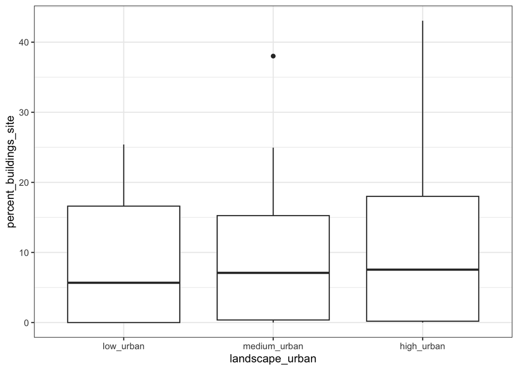

```r
sites <- full_join(popden, urbanization, by = "TOWN")

sites$landscape_urban<-factor(sites$landscape_urban,
                              levels = c("low_urban", "medium_urban",
                                         "high_urban"))

sites$local_urban<-factor(sites$local_urban,
                          levels = c("low_urban", "medium_urban",
                                     "high_urban"))

ggplot(sites, aes(x=landscape_urban, y = percent_buildings_site))+
  geom_boxplot()+
  theme_bw()
```

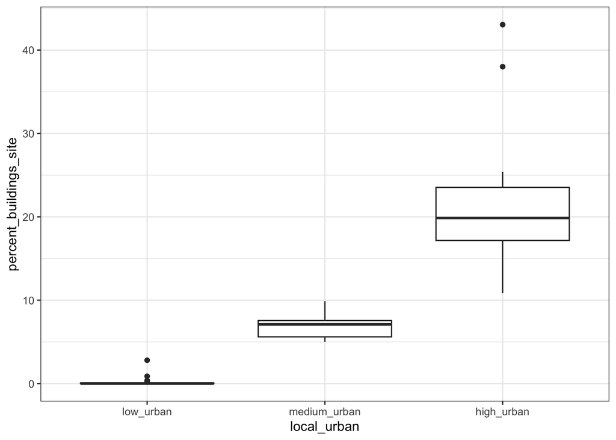

```r
ggplot(sites, aes(x=local_urban, y = percent_buildings_site))+
  geom_boxplot()+
  theme_bw()
```

```r
# At the landscape scale, we see there is not too much of a difference
#   between the percent buildings within each urban landscape
#   type except in the high urban category the data is skewed a bit.
#   So at the high urban level, there are a lot of sites with low
#   percent buildings, but a few sites with a lot of buildings.
#   To me, this indicates that the percent buildings may not be a
#   good predictor of spider activity at the landscape level.

# At the local scale, we see a different pattern, there is a lot of
#   difference in the percent buildings at each site, with a very nice
#   trend of low percent buildings at low urban sites, to high percent
#   buildings at high urban sites.  If urbanization is going to matter
#   for spider activity, I would predict it would be important at the
#   local level
#
```

**Q3** Now let’s explore the data by creating histograms. Use your merged data to explore the distribution of the data for “Naraneus”: number of adult female Araneus diadematus spiders caught per 0.2*0.2 km site. Then use the “spiders.csv” datset to explore “EfSurface” - area of the web capture zone (cm2), and “CTsize” - spider cephalothorax width (cm). What type of mixed model (lmer or glmer) should you use for each variable and why? What distribution does the data use? If there are multiple possibilities for a single variable, what are there?

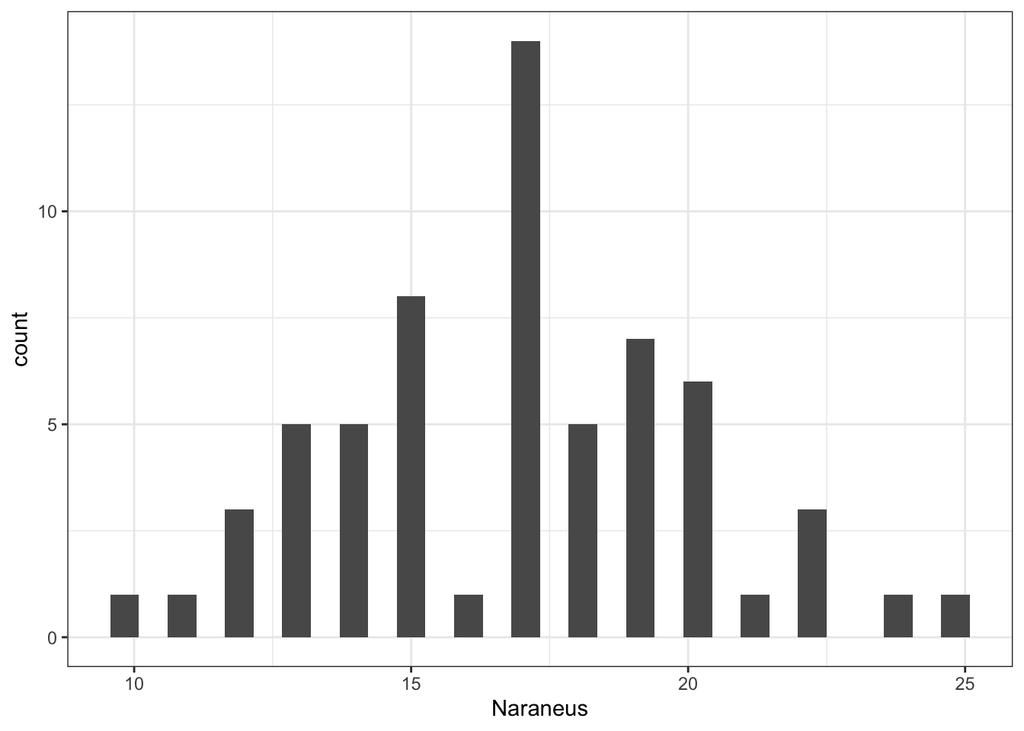

```r
ggplot(sites, aes(x=Naraneus))+
  geom_histogram()+
  theme_bw()
```

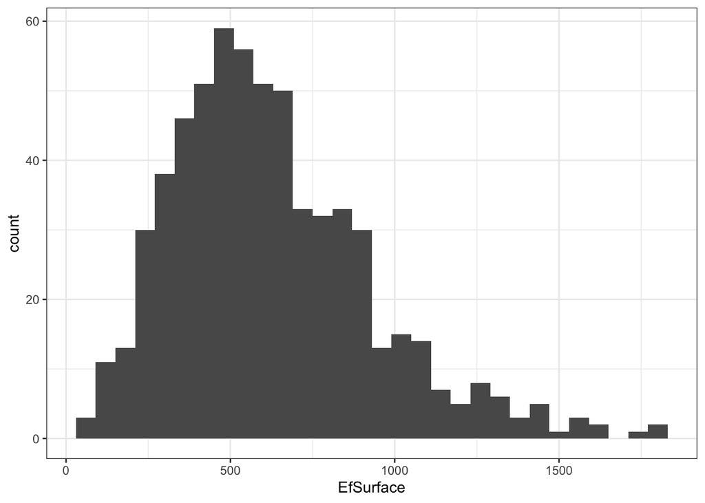

```r
# Here I would use a glmer() and a poisson distribution because even
#   though the data looks normal, the data are counts. However this
#   brings up the issue of overdispersion that I was not aware of before.
#   What that means is that sometimes a dataset has too large of a
#   variance to fit a poisson (which is somewhat limited because)
#   it's a distribution with only a single parameter. So you may
#   want to try something that deals with this (e.g. negative
#   binomial).  We did not talk about this in class, so I'll go over it
#   in class.

ggplot(spiders, aes(x=EfSurface))+
  geom_histogram()+
  theme_bw()
```

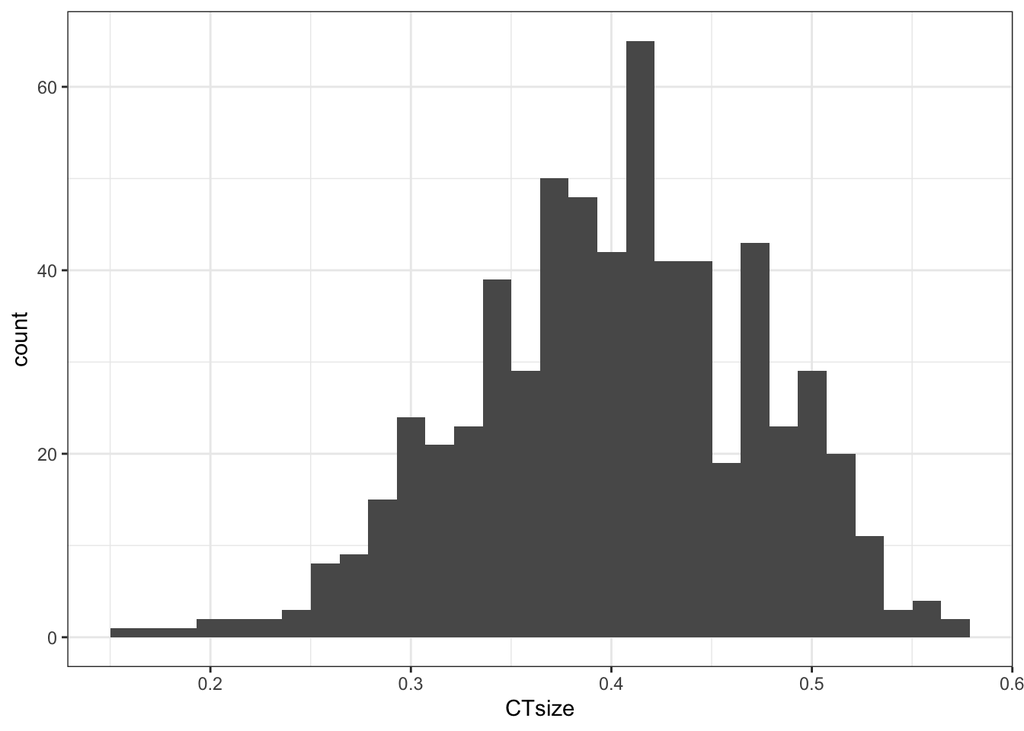

```r
# Since the data here are the area of web capture, I would start with
#   a lmer() because this type of data could follow a normal distirbution.
#   However, since the data also appears skewed, and is continuous, I
#   would also double check that a glmer() with a skewed distribution such
#   as inverse gaussian or gamma isn't better than the lmer().  Or of course
#   you could log transform the data, but I won't do that here.

ggplot(spiders, aes(x=CTsize))+
  geom_histogram()+
  theme_bw()
```

```r
# Body size data should also be continuous and follow a normal distribution,
#   so I would use a lmer() here. There is a small skew in the data, but I
#   think this should be the best model to use because it's not as dramatic
#   of a skew as in the previous example.
```

## Mized Effects Models

### Mixed Effects Models

**Q4** Let’s start by exploring the patterns in the spider abundance data (Naraneus). We will create a mixed effects model to understand how urbanization at the local and landscape scale affect the number of Naraneus spiders. But first let’s consider the random effects. What would you use for your random effects and why?

```r
# I would use PLOT as a random intercept these data. There
#   could be some reason these data are not independent
#   among each plot (like temperature, humidity, prey
#   abundance, etc).
```

**Q5** Create a mixed effects model that explores: Naraneus $\sim$ landscape_urban + local_urban + random effects. We determined in question 2 that there are differences in the percent buildings at these scales, so perhaps these categorical variables will be enough to capture those trends. Summarize the results, and include in your summary a discussion of the variance components.

```r
mod_5 <- glmer(Naraneus ~ landscape_urban + local_urban + (1|PLOT),
               data = sites, family = poisson)

##This is an example of a negative binomial model
mod_5_nb <- glmer.nb(Naraneus ~ landscape_urban + local_urban + (1|PLOT),
               data = sites, verbose=TRUE)
```

[output not shown]

```r
Anova(mod_5)
```

```
## Analysis of Deviance Table (Type II Wald chisquare tests)
##
## Response: Naraneus
##                  Chisq Df Pr(>Chisq)
## landscape_urban 2.4674  2     0.2912
## local_urban     0.7429  2     0.6897
```

```r
Anova(mod_5_nb)
```

```
## Analysis of Deviance Table (Type II Wald chisquare tests)
##
## Response: Naraneus
##                  Chisq Df Pr(>Chisq)
## landscape_urban 2.5281  2     0.2825
## local_urban     0.7582  2     0.6845
```

```r
AICtab(mod_5, mod_5_nb)
```

```
##          dAIC df
## mod_5    0    6
## mod_5_nb 2    7
```

```r
# you can see from this the poisson and NB models are indistinguishable.

r.squaredGLMM(mod_5)
```

```
##                  R2m        R2c
## delta     0.05270785 0.05270785
## lognormal 0.05417252 0.05417252
## trigamma  0.05123949 0.05123949
```

```r
# The number of spiders appears to not respond to the level of
#   urbanization. The fixed effects explain ~5% of the variation
#   and the fixed and random effects together explain ~5% of the
#   variation.
```

**Q6** Create a figure that demonstrates your results.

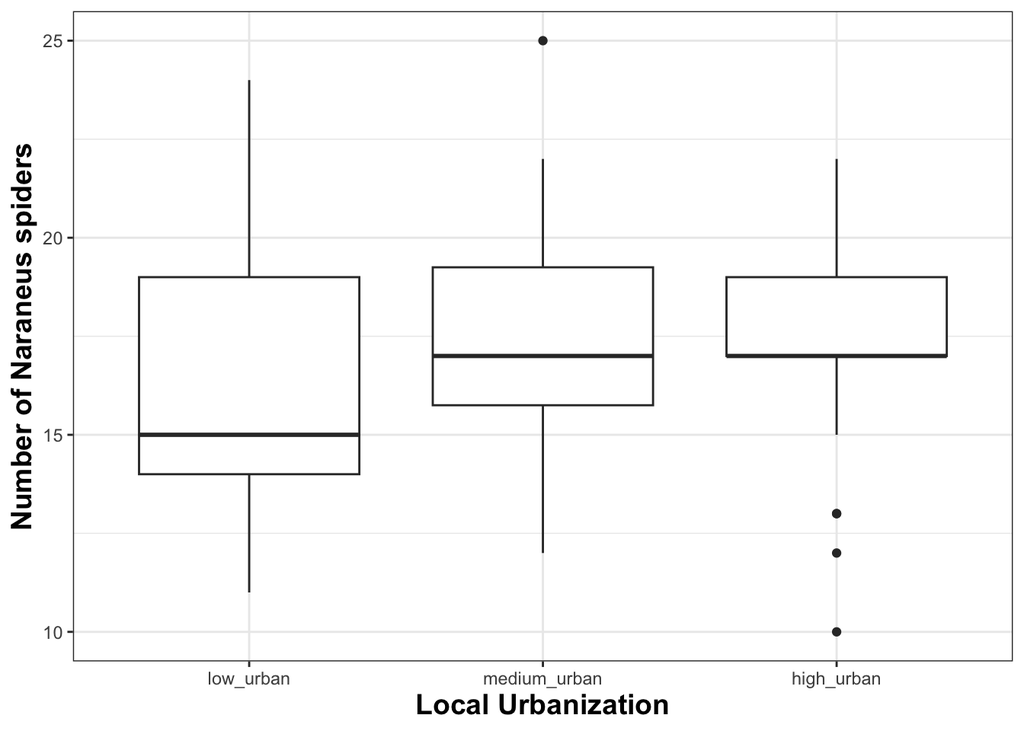

```r
ggplot(sites, aes(x=local_urban, y = Naraneus))+
  geom_boxplot()+
  theme_bw()+
  theme(axis.title = element_text(face="bold", size=14))+
  labs(x = "Local Urbanization", y = "Number of Naraneus spiders")
```

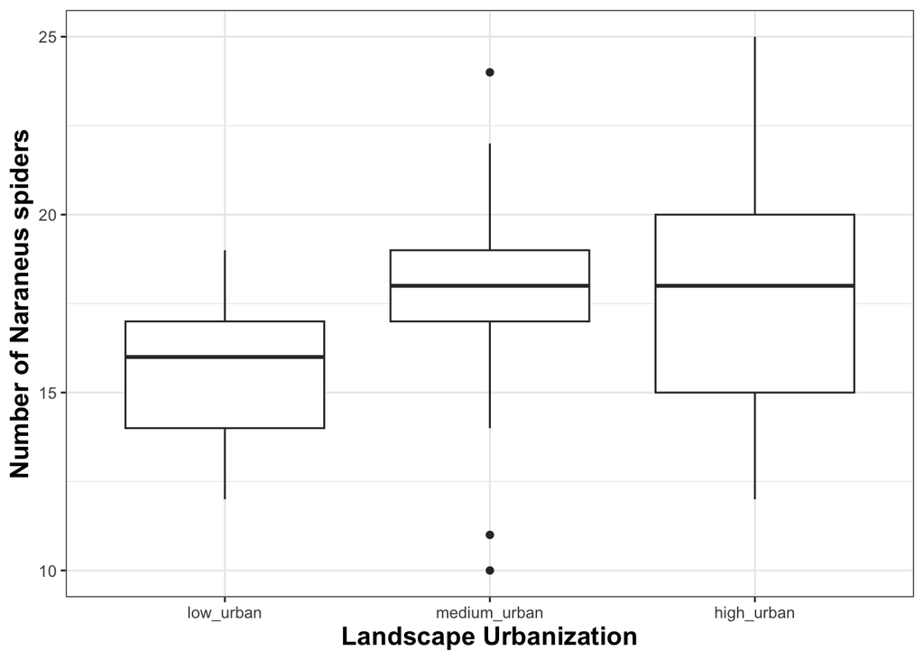

```r
ggplot(sites, aes(x=landscape_urban, y = Naraneus))+
  geom_boxplot()+
  theme_bw()+
  theme(axis.title = element_text(face="bold", size=14))+
  labs(x = "Landscape Urbanization", y = "Number of Naraneus spiders")
```

**Q7** Next, let’s look at the area of the web capture (EfSurface) for spiders in these landscapes. Based on our thoughts from question 3, the distribution of the data is such that it is unclear if we should analyze the data using a `lmer()` or a `glmer()`. Run both models with your dependent variable as EfSurface, your independent variables as landscape_urban + local_urban, and a random effect for plot. Compare your model outputs. Which model describes the data better? Describe the results of the best fitting model. Plot a figure to represent this.

```r
mod_7_a <- lmer(EfSurface ~ landscape_urban + local_urban + (1|PLOT),
               data = spiders, REML = TRUE )

mod_7_b <- glmer(EfSurface ~ landscape_urban + local_urban + (1|PLOT),
               data = spiders, family=Gamma )

Anova(mod_7_a, test.statistic = "Chisq")
```

```
## Analysis of Deviance Table (Type II Wald chisquare tests)
##
## Response: EfSurface
##                   Chisq Df Pr(>Chisq)
## landscape_urban  3.8157  2     0.1484
## local_urban     22.6651  2  1.198e-05 ***
## ---
## Signif. codes:  0 '***' 0.001 '**' 0.01 '*' 0.05 '.' 0.1 ' ' 1
```

```r
Anova(mod_7_b)
```

```
## Analysis of Deviance Table (Type II Wald chisquare tests)
##
## Response: EfSurface
##                   Chisq Df Pr(>Chisq)
## landscape_urban  2.5473  2     0.2798
## local_urban     20.6794  2  3.232e-05 ***
## ---
## Signif. codes:  0 '***' 0.001 '**' 0.01 '*' 0.05 '.' 0.1 ' ' 1
```

```r
#both functions show you the same result
anova(mod_7_a, mod_7_b)
```

```
## Data: spiders
## Models:
## mod_7_a: EfSurface ~ landscape_urban + local_urban + (1 | PLOT)
## mod_7_b: EfSurface ~ landscape_urban + local_urban + (1 | PLOT)
##         npar    AIC    BIC  logLik deviance  Chisq Df Pr(>Chisq)
## mod_7_a    7 8721.0 8752.0 -4353.5   8707.0
## mod_7_b    7 8615.5 8646.6 -4300.8   8601.5 105.47  0
```

```r
AICtab(mod_7_a, mod_7_b)
```

```
##         dAIC df
## mod_7_b  0.0 7
## mod_7_a 59.4 7
```

```r
# So based in AIC (and other metrics), it appears that the `glmer()` with
#   the Gamma function fits the data better because it has the lowest AIC
#   value.

Anova(mod_7_b)
```

```
## Analysis of Deviance Table (Type II Wald chisquare tests)
##
## Response: EfSurface
##                   Chisq Df Pr(>Chisq)
## landscape_urban  2.5473  2     0.2798
## local_urban     20.6794  2  3.232e-05 ***
## ---
## Signif. codes:  0 '***' 0.001 '**' 0.01 '*' 0.05 '.' 0.1 ' ' 1
```

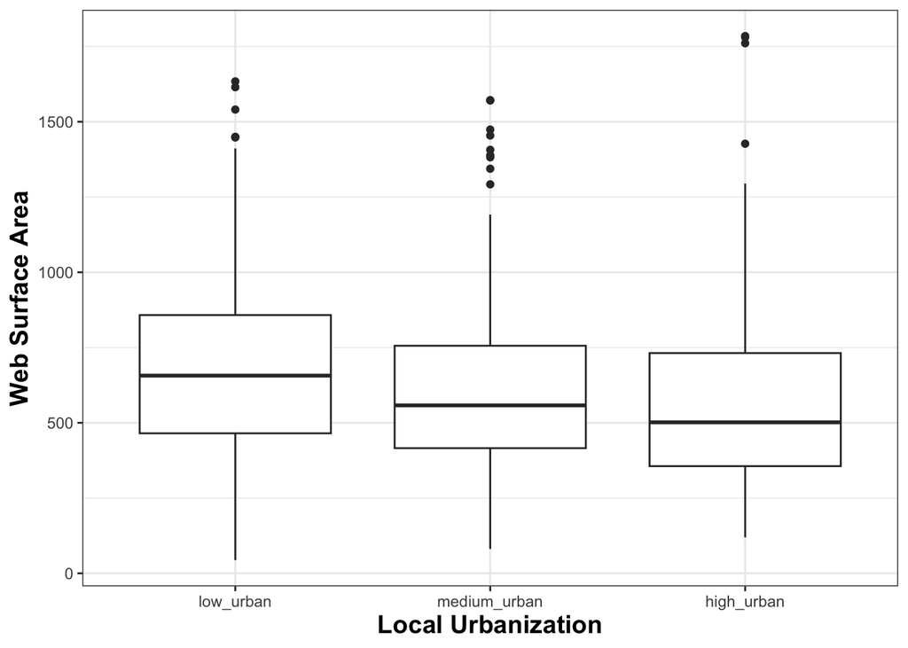

```r
#  Based on our model, urbanization at the landscape level does not
#   affect web surface area. But local urban landscapes does.


spiders$local_urban<-factor(spiders$local_urban,
                          levels = c("low_urban", "medium_urban",
                                     "high_urban"))

ggplot(spiders, aes(x=local_urban, y = EfSurface))+
  geom_boxplot()+
  theme_bw()+
  theme(axis.title = element_text(face="bold", size=14))+
  labs(x = "Local Urbanization", y = "Web Surface Area")
```